# Group_Project 3&4

Ananya Sharma

07/02/2022

[figure not shown]

## INTRODUCTION

- `Purpose:` The purpose is to understand what factors cause attrition amongst the employees of IBM, using logistic model method.
- Creating a corr plot to get a general idea of the correlation amongst the different variables.

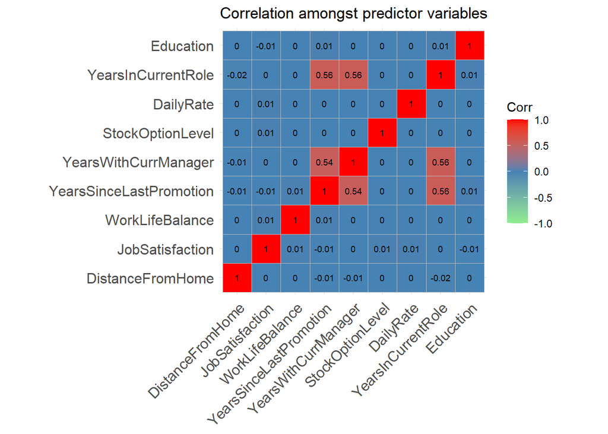

```r
Ibm_corr= subset(Data_ibm, select=c(DistanceFromHome,JobSatisfaction,WorkLifeBalance, YearsSinceLastPromotion,YearsWithCurrManager,StockOptionLevel,DailyRate,YearsInCurrentRole,Education))

#Ibm_corr

X1<-na.omit(Ibm_corr)     # removing NA Values

corplotting <- cor(X1)

ggcorrplot((round(corplotting,2)),
           colors = c("lightgreen", "steelblue", "red"),lab = TRUE,lab_size =2.5) +
  ggtitle("Correlation amongst predictor variables")
```

- The corr plot shows that almost all the variables are showing a negligible correlation with each other.However, years in current role has a slight correlation to the tune of 0.56 with the Years with last promotion an year with the current manager.